# Visualising herbivory and climate change literature

`ggplot2` is a hugely powerful R package which enables the creation of high quality scientific charting and visualisation for communication.

This note walks through some basics for creating charts to illustrate the literature review but there are lots of resources for chart creation of which [this course](https://rstudio-conf-2022.github.io/ggplot2-graphic-design/) really showcases what is possible.

## Load libraries and import data

```r
## load libraries

library(pacman)
pacman::p_load(tidyverse, readxl, here, skimr, overviewR, ggmap, gt, gtsummary, DataExplorer, gtExtras, rphylopic, magick)       ## readxl is needed to load excel files into R


path <- here::here("data")         ## the `here` package helps with file paths


xls <- list.files(path, "xls", full.names = TRUE)

data <- readxl::read_xlsx(xls[1]) |>
  janitor::clean_names()
```

```r
introduce(data)
```

```
# A tibble: 1 × 9
   rows columns discrete_columns conti…¹ all_m…² total…³ compl…⁴ total…⁵ memor…⁶
  <int>   <int>            <int>   <int>   <int>   <int>   <int>   <int>   <dbl>
1    45      99               82       0      17    1815       0    4455  176360
# … with abbreviated variable names ¹continuous_columns, ²all_missing_columns,
#   ³total_missing_values, ⁴complete_rows, ⁵total_observations, ⁶memory_usage
```

## Data wrangling

The dataset is wide - that is each variable or category has its own column, but for analysis and plotting it might be easier to groups some of the variables to make the data more hierarchical. For example *climate change outcome* has a set of outcome categories each of which have a direction of change.

The `skimr` package gives us a rapid overview of the data structure…

```r
skimr::skim(data)
```

Data summary

| Name | data |
| --- | --- |
| Number of rows | 45 |
| Number of columns | 99 |
| _______________________ |  |
| Column type frequency: |  |
| character | 82 |
| logical | 17 |
| ________________________ |  |
| Group variables | None |

**Variable type: character**

| skim_variable | n_missing | complete_rate | min | max | empty | n_unique | whitespace |
| --- | --- | --- | --- | --- | --- | --- | --- |
| item | 0 | 1.00 | 24 | 44 | 0 | 45 | 0 |
| title | 0 | 1.00 | 66 | 160 | 0 | 27 | 0 |
| wildlife_trusts_relevance | 0 | 1.00 | 4 | 4 | 0 | 1 | 0 |
| evidence_point | 0 | 1.00 | 17 | 17 | 0 | 7 | 0 |
| herbivore_species_or_simulation_exposure | 2 | 0.96 | 14 | 34 | 0 | 9 | 0 |
| horses_equines | 43 | 0.04 | 16 | 22 | 0 | 2 | 0 |
| cows_bovines | 12 | 0.73 | 6 | 26 | 0 | 11 | 0 |
| sheep_ovines | 33 | 0.27 | 6 | 21 | 0 | 4 | 0 |
| livestock_not_stated_11 | 44 | 0.02 | 23 | 23 | 0 | 1 | 0 |
| simulated_grazing_13 | 39 | 0.13 | 8 | 8 | 0 | 1 | 0 |
| mixed_herd_or_single_species_exposure | 0 | 1.00 | 6 | 15 | 0 | 3 | 0 |
| climate_effect_outcome | 1 | 0.98 | 12 | 218 | 0 | 14 | 0 |
| soil_carbon | 36 | 0.20 | 8 | 10 | 0 | 4 | 0 |
| digestive_methane_emissions_production_or_live_weight | 37 | 0.18 | 8 | 10 | 0 | 3 | 0 |
| digestive_methane_emissions_land_area | 41 | 0.09 | 9 | 9 | 0 | 2 | 0 |
| digestive_methane_emissions_per_animal | 40 | 0.11 | 8 | 10 | 0 | 4 | 0 |
| methane_flux_emissions | 34 | 0.24 | 8 | 10 | 0 | 4 | 0 |
| nitrous_oxide | 23 | 0.49 | 8 | 10 | 0 | 3 | 0 |
| co2_flux_emissions | 33 | 0.27 | 9 | 10 | 0 | 3 | 0 |
| above_ground_biomass | 42 | 0.07 | 9 | 10 | 0 | 2 | 0 |
| total_ghg_emissions_co2_equiv | 39 | 0.13 | 8 | 9 | 0 | 3 | 0 |
| root_biomass | 42 | 0.07 | 9 | 10 | 0 | 2 | 0 |
| direction_of_climate_change_outcome | 2 | 0.96 | 10 | 20 | 0 | 4 | 0 |
| herbivore_species_or_other_comparator | 0 | 1.00 | 7 | 30 | 0 | 9 | 0 |
| sheep_ovine | 35 | 0.22 | 6 | 21 | 0 | 4 | 0 |
| cows_bovine | 22 | 0.51 | 10 | 26 | 0 | 7 | 0 |
| mowing | 44 | 0.02 | 7 | 7 | 0 | 1 | 0 |
| cutting | 44 | 0.02 | 15 | 15 | 0 | 1 | 0 |
| no_herbivore_or_simulation | 35 | 0.22 | 27 | 27 | 0 | 1 | 0 |
| not_applicable | 44 | 0.02 | 15 | 15 | 0 | 1 | 0 |

[output cut: 52 more lines]

**Variable type: logical**

| skim_variable | n_missing | complete_rate | mean | count |
| --- | --- | --- | --- | --- |
| goats_caprines | 45 | 0 | NaN | : |
| deer_cervine_10 | 45 | 0 | NaN | : |
| simulated_browsing | 45 | 0 | NaN | : |
| albedo | 45 | 0 | NaN | : |
| dung_methane_emissions | 45 | 0 | NaN | : |
| wildfire | 45 | 0 | NaN | : |
| goats_caprine | 45 | 0 | NaN | : |
| horses_equine | 45 | 0 | NaN | : |
| deer_cervine_35 | 45 | 0 | NaN | : |
| not_available | 45 | 0 | NaN | : |
| global | 45 | 0 | NaN | : |
| africa | 45 | 0 | NaN | : |
| antarctica | 45 | 0 | NaN | : |
| asia | 45 | 0 | NaN | : |
| south_america_and_central_america | 45 | 0 | NaN | : |
| habitat_type_exposure | 45 | 0 | NaN | : |
| habitat_type_comparator | 45 | 0 | NaN | : |

Lets try and reshape the climate effects variables.

```r
climate_effect <- data |>
  select(item, title, albedo:direction_of_climate_change_outcome)

climate_effect_long <- climate_effect |>
  pivot_longer(names_to = "vars", values_to = "vals", cols = 3:16)

pluck(climate_effect_long, "vars") |>
  unique()
```

```
 [1] "albedo"
 [2] "soil_carbon"
 [3] "digestive_methane_emissions_production_or_live_weight"
 [4] "digestive_methane_emissions_land_area"
 [5] "digestive_methane_emissions_per_animal"
 [6] "dung_methane_emissions"
 [7] "methane_flux_emissions"
 [8] "nitrous_oxide"
 [9] "co2_flux_emissions"
[10] "above_ground_biomass"
[11] "total_ghg_emissions_co2_equiv"
[12] "wildfire"
[13] "root_biomass"
[14] "direction_of_climate_change_outcome"
```

### Recoding variables to create groups

```r
cel <- climate_effect_long |>
  mutate(var_cat = case_when(str_detect(vars, "methane") ~ "methane",
                             str_detect(vars, "biomass") ~ "biomass",
                             str_detect(vars, "emissions") ~ "emissions",
                             TRUE ~ vars))

  gt <- cel |>
  janitor::tabyl(vars, vals) |>
  gt::gt()

gt |>
  tab_header(title = "Climate change outcomes") |>
  tab_spanner(
    label = "Outcome",
    columns = 2:9
  ) |>
  tab_row_group(
    label = "Biomass",
    rows = c(1, 11)
  ) |>
  tab_row_group(
    label = "Methane",
    rows = c(5:9)
  )
```

Climate change outcomes

| vars | Outcome -Cooling effect | Outcome -Decrease | Outcome -Heating effect | Outcome -Increase | Outcome -No change | Outcome -Unclear | Outcome -Unclear or multiple | Outcome NA_ |
| --- | --- | --- | --- | --- | --- | --- | --- | --- |
| Methane |  |  |  |  |  |  |  |  |
| digestive_methane_emissions_per_animal | 0 | 2 | 0 | 1 | 1 | 1 | 0 | 40 |
| digestive_methane_emissions_production_or_live_weight | 0 | 0 | 0 | 1 | 6 | 1 | 0 | 37 |
| direction_of_climate_change_outcome | 7 | 0 | 15 | 0 | 12 | 0 | 9 | 2 |
| dung_methane_emissions | 0 | 0 | 0 | 0 | 0 | 0 | 0 | 45 |
| methane_flux_emissions | 0 | 1 | 0 | 4 | 5 | 1 | 0 | 34 |
| Biomass |  |  |  |  |  |  |  |  |
| above_ground_biomass | 0 | 2 | 0 | 0 | 1 | 0 | 0 | 42 |
| root_biomass | 0 | 0 | 0 | 2 | 1 | 0 | 0 | 42 |
| albedo | 0 | 0 | 0 | 0 | 0 | 0 | 0 | 45 |
| co2_flux_emissions | 0 | 5 | 0 | 5 | 2 | 0 | 0 | 33 |
| digestive_methane_emissions_land_area | 0 | 1 | 0 | 3 | 0 | 0 | 0 | 41 |
| nitrous_oxide | 0 | 0 | 0 | 10 | 10 | 2 | 0 | 23 |
| soil_carbon | 0 | 3 | 0 | 1 | 4 | 1 | 0 | 36 |
| total_ghg_emissions_co2_equiv | 0 | 2 | 0 | 3 | 0 | 1 | 0 | 39 |
| wildfire | 0 | 0 | 0 | 0 | 0 | 0 | 0 | 45 |

Lets do similar data on herbivores.

```r
#| label: download phylopic images

dir.create(paste0(here(), "/images"))
image_path <- here("images")

taxa <- "sheep"

ns <- name_search(taxa, options = "namebankID")[1,]

id <- name_images(uuid = ns$uid[1])

uid <- id$same[[4]]$uid

size <- 64

img <- paste0("http://phylopic.org/assets/images/submissions/", uid, ".", size, ".png") %>%
    image_read()

img |>
  image_write(paste0(image_path, "/sheep.png"))
```

### Table decoration with images

```r
## Create a table of images
image_files <- list.files(here::here("images"), "png", full.names = T)
taxa <- c("Cows", "Goat", "Horses", "Sheep")
image_tab <- tibble(taxa, image_files)

data |>
  select(item, contains("ine"), -continent_and_country) |>
  pivot_longer(names_to = "Herbivores", values_to = "Breed", cols = 2:11, values_drop_na = TRUE) |>
  mutate(Herbivore_Group = case_when(str_detect(Herbivores, "ines") ~ "Outcome",
                                TRUE ~ "Comparator")) |>
  group_by(Herbivore_Group, Herbivores) |>
  count(Breed) |>
  mutate(Herbivores = str_remove_all(Herbivores, "_.*ine?."),
         Herbivores = str_to_title(Herbivores)) |>
  pivot_wider(names_from = "Herbivore_Group", values_from = "n", values_fill = 0) |>
  mutate(Breed = str_remove(Breed, "-"),
         Breed = str_remove(Breed, "\\r\\n")) |>
  left_join(image_tab, by = c("Herbivores" = "taxa")) |>
  select(Herbivory = image_files, Breed, Outcome, Comparator) |>
  gt::gt() |>
    gt_img_rows(Herbivory, img_source = "local") |>
  gt_theme_guardian()
```

| Herbivory | Breed | Outcome | Comparator |
| --- | --- | --- | --- |
| Cows |  |  |  |
|  | Aberdeen Angus | 1 | 1 |
|  | Aberdeen Angus X Limousin | 0 | 2 |
|  | Breed not stated | 13 | 6 |
|  | Charolais | 1 | 1 |
|  | Holstein Fresian | 8 | 8 |
|  | Limousin X | 2 | 4 |
|  | Limousin X-Welsh Black | 1 | 1 |
|  | Belted Galloway | 1 | 0 |
|  | Belted Galloway-Dexters | 1 | 0 |
|  | Hungarian grey cattle | 1 | 0 |
|  | Luing | 2 | 0 |
|  | Welsh Black | 2 | 0 |
| Sheep |  |  |  |
|  | Beulah Speckled Face | 3 | 3 |
|  | Breed not stated | 6 | 5 |
|  | Laxta | 1 | 1 |
|  | Welsh Mountain sheep | 2 | 1 |
| Horses |  |  |  |
|  | Shetland ponies | 1 | 0 |
|  | Welsh mountain ponies | 1 | 0 |

## Basic template for plotting categorical variables

### Select categorical variables

```r
## Select categorical variables
chr_vars <- select_if(data, is.character) |>
  janitor::clean_names()          ## this function converts variable names to snake case which makes them much more consistent

glimpse(chr_vars)
```

```
Rows: 45
Columns: 82
$ item                                                  <chr> "Abdalla (2009) …
$ title                                                 <chr> "Application of …
$ wildlife_trusts_relevance                             <chr> "-Yes", "-Yes", …
$ evidence_point                                        <chr> "-Evidence point…
$ herbivore_species_or_simulation_exposure              <chr> "Cows (bovines)"…
$ horses_equines                                        <chr> NA, NA, NA, NA, …
$ cows_bovines                                          <chr> "-Breed not stat…
$ sheep_ovines                                          <chr> NA, NA, NA, NA, …
$ livestock_not_stated_11                               <chr> NA, NA, NA, NA, …
$ simulated_grazing_13                                  <chr> NA, NA, NA, NA, …
$ mixed_herd_or_single_species_exposure                 <chr> "-Single species…
$ climate_effect_outcome                                <chr> "-Nitrous oxide"…
$ soil_carbon                                           <chr> NA, NA, "-No cha…
```

[output cut: 69 more lines]

### Ordered bar charts (recommended)

We’ll use `ggplot2` which is a hugely powerful and (hopefully) intuitive package for high quality production charting.

Lets plot `climate_change_outcome`

The first step is to count the frequency of each category within the variable:

```r
## the |> symbol is called a "pipe" . It says "do the instruction on the right hand side to the data on the left hand side. So... count categories in the variable climate_effect_outcome in the data set chr_vars

counts <- chr_vars  |>
  count(climate_effect_outcome)

counts
```

```
# A tibble: 15 × 2
   climate_effect_outcome                                                      n
   <chr>                                                                   <int>
 1 "-CO2 flux_emissions"                                                       1
 2 "-CO2 flux_emissions\r\n-Soil carbon"                                       1
 3 "-Digestive methane emissions (Land Area)"                                  3
 4 "-Digestive methane emissions (per animal)"                                 1
 5 "-Digestive methane emissions (Production or Live Weight)"                  4
 6 "-Digestive methane emissions (Production or Live Weight)\r\n-Digestiv…     3
 7 "-Digestive methane emissions (Production or Live Weight)\r\n-Nitrous …     1
 8 "-Methane flux_emissions\r\n-Total GHG Emissions (CO2 equiv.)"              1
 9 "-Nitrous oxide"                                                           12
10 "-Nitrous oxide\r\n-CO2 flux_emissions\r\n-Methane flux_emissions"          6
11 "-Nitrous oxide\r\n-CO2 flux_emissions\r\n-Methane flux_emissions\r\n-…     3
12 "-Root biomass\r\n-Soil carbon"                                             1
13 "-Soil carbon"                                                              5
14 "-Soil carbon\r\n-Above ground biomass\r\n-Root biomass"                    2
15  <NA>                                                                       1
```

We can see there are 15 in the data.

We can now construct a bar (column) chart using gg plot

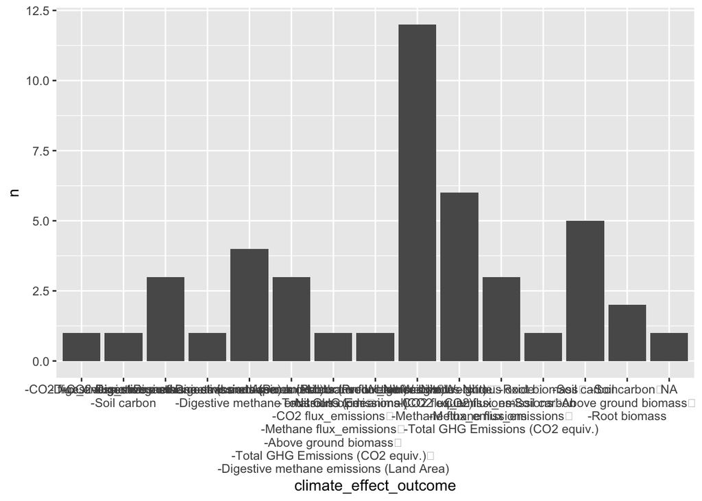

```r
counts |>
  ggplot(aes(x = climate_effect_outcome, y = n)) +  ## we have to wrap x and y variables in aes()
  geom_col()                                        ## geom_col() plots bars
```

It’s a bit of a mess…

Note that `ggplot` is built on the idea that charts are built in layers - axes, annotations, data, panels and plot areas and so on, and each layer we add needs a `+` sign -

In the code below we tell ggplot to add columns to represent the data on the chart by `+ geom_col()`

1. Labels are ?duplicated and rather messy
2. The y axis label is redundant
3. The x axis needs to be integer and we need to label it correctly
4. We need to add titles etc
5. We should remove (or relabel) NAs.

Let’s tackle these.

### Labelling or modifying axes labels, adding titles

This is controlled by `labs()`

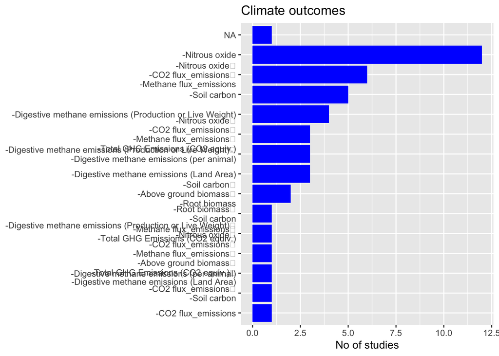

```r
g <- counts |>
  ggplot(aes(reorder(climate_effect_outcome, n), n)) +
  geom_col(fill = "blue") +                             ## (fill = ... controls the colour of the bars)
  labs(y = "No of studies",
       x = NULL,
       title = "Climate outcomes") +
  coord_flip()

g
```

Positions of titles, axes labels, font sizes and so on are controlled by `theme()`

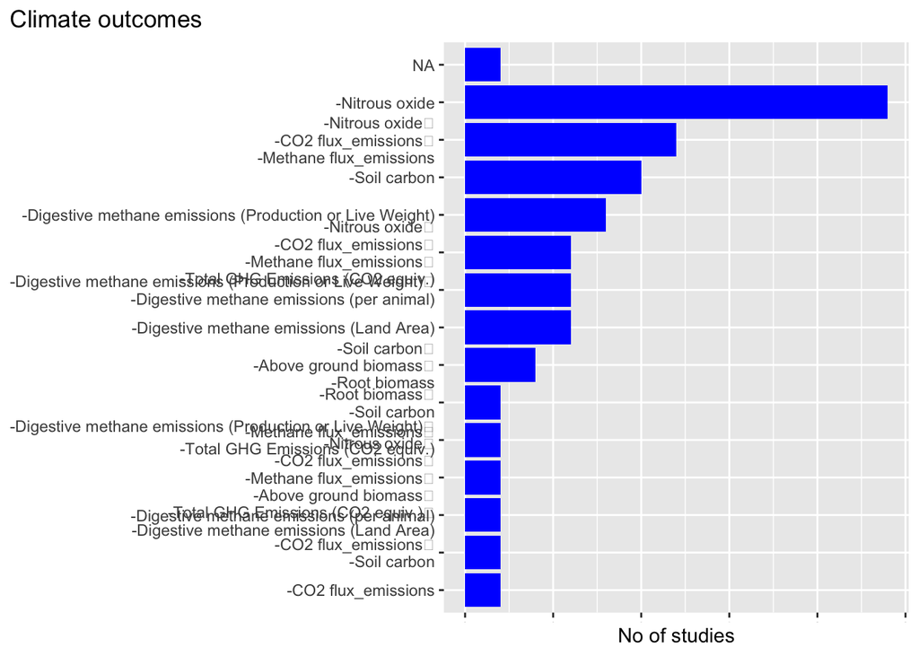

```r
g <- g +
  theme(plot.title.position = "plot",
        axis.text.x = element_text(size = .5))

g
```

### Further modifications

The value labels still need tidying but that may best be done in the data. We can change the colour of the bars and the background.

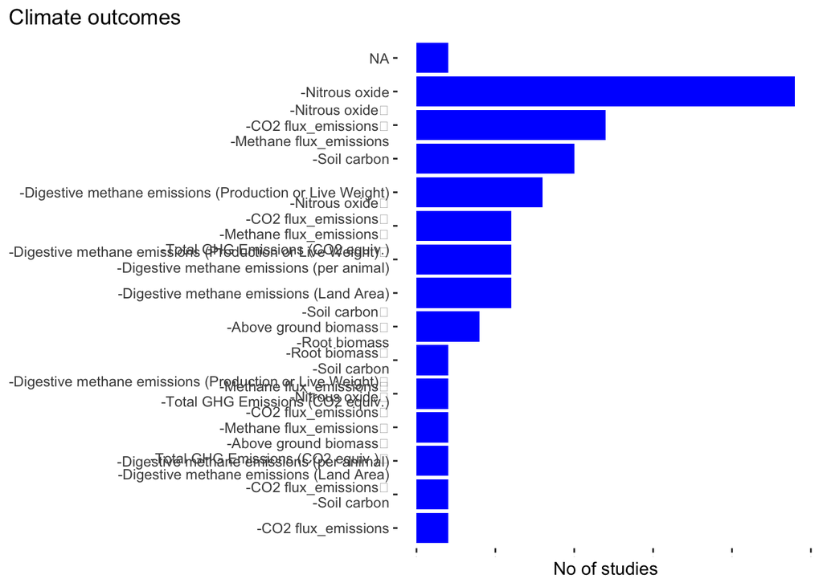

```r
g +
  theme(panel.background = element_blank())      ## removes panel background
```

### Putting it all together

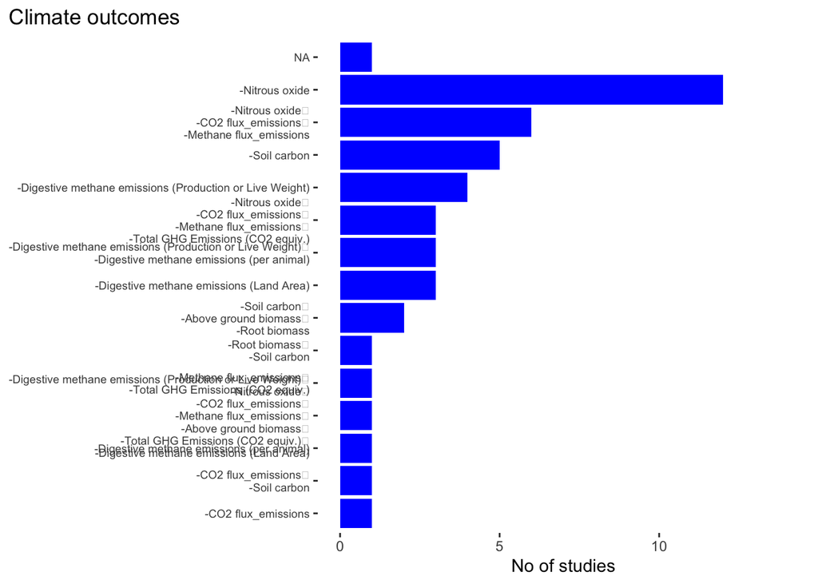

```r
chr_vars |>
  count(climate_effect_outcome) |>
  ggplot(aes(reorder(climate_effect_outcome, n), n)) +
  geom_col(fill = "blue") +
  labs(y = "No of studies",
       x = NULL,
       title = "Climate outcomes") +
  ylim(c(0, 14)) +
  coord_flip() +
  theme(plot.title.position = "plot",
        axis.text.y = element_text(size = 7),
        panel.background = element_blank())
```

### Making it generic - writing a function

Now we have a basic template, it would be useful to reuse this for other variables.

To do this we can write a function - like a macro - which in R is very easy - just need to wrap our code in `function()` and identify the input we want to change - which in this case is other variables. Lets call the function `plot_ordered_bar_chart`. The core looks like this…

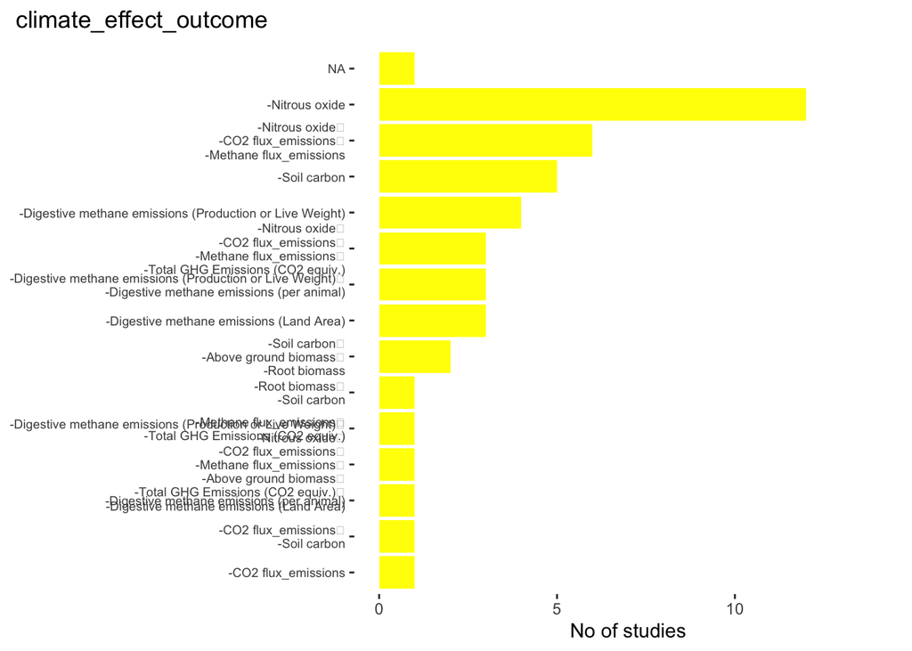

```r
plot_ordered_bar_chart <- function(df, var){
  df = df
  var <- enquo(var)
  df |>
    count(!!var) |>
  ggplot(aes(reorder(!!var, n), n)) +
  geom_col(fill = "yellow") +
  labs(y = "No of studies",
       x = NULL,
       title = var) +
  ylim(c(0, 14)) +
  coord_flip() +
  theme(plot.title.position = "plot",
        axis.text.y = element_text(size = 7),
        panel.background = element_blank())

}



plot_ordered_bar_chart(chr_vars, var= climate_effect_outcome)
```

```r
variables <- colnames(chr_vars)

plot_ordered_bar_chart(chr_vars, horses_equines)
```

[output not shown]

### Pie chart (not recommended

Pie charts are unexpectedly hard to to create in R - there is no geom in ggplot for example

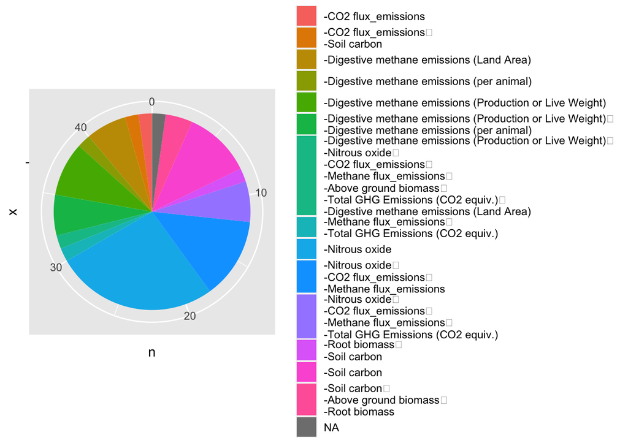

```r
counts |>
  ggplot(aes(x="", y=n, fill=climate_effect_outcome)) +
  geom_bar(stat="identity", width=1) +
  coord_polar("y", start=0)
```

### Small multiples

We might want to compare frequencies across multiple variables, for example

```r
## lets create a frequency table of the number of breeds mentioned in studes for each herbivore group

grouped <- data |>
  select(contains("vine")) |>
  pivot_longer(names_to = "herbivore", values_to = "breed", cols = 1:6) |>
  group_by(herbivore) |>
  count(breed)

grouped
```

```
# A tibble: 32 × 3
# Groups:   herbivore [6]
   herbivore    breed                             n
   <chr>        <chr>                         <int>
 1 cows_bovine  "-Aberdeen Angus"                 1
 2 cows_bovine  "-Aberdeen Angus X Limousin"      2
 3 cows_bovine  "-Breed not stated"               6
 4 cows_bovine  "-Charolais"                      1
 5 cows_bovine  "-Holstein Fresian"               8
 6 cows_bovine  "-Limousin X"                     4
 7 cows_bovine  "-Limousin X\r\n-Welsh Black"     1
 8 cows_bovine   <NA>                            22
 9 cows_bovines "-Aberdeen Angus"                 1
10 cows_bovines "-Belted Galloway"                1
# … with 22 more rows
```

[figure not shown]

```r
grouped |>
  drop_na() |>
  ggplot(aes(herbivore, n, fill = breed)) +
  geom_col(position = "fill") +
  scale_y_continuous(labels = scales::percent_format())
```

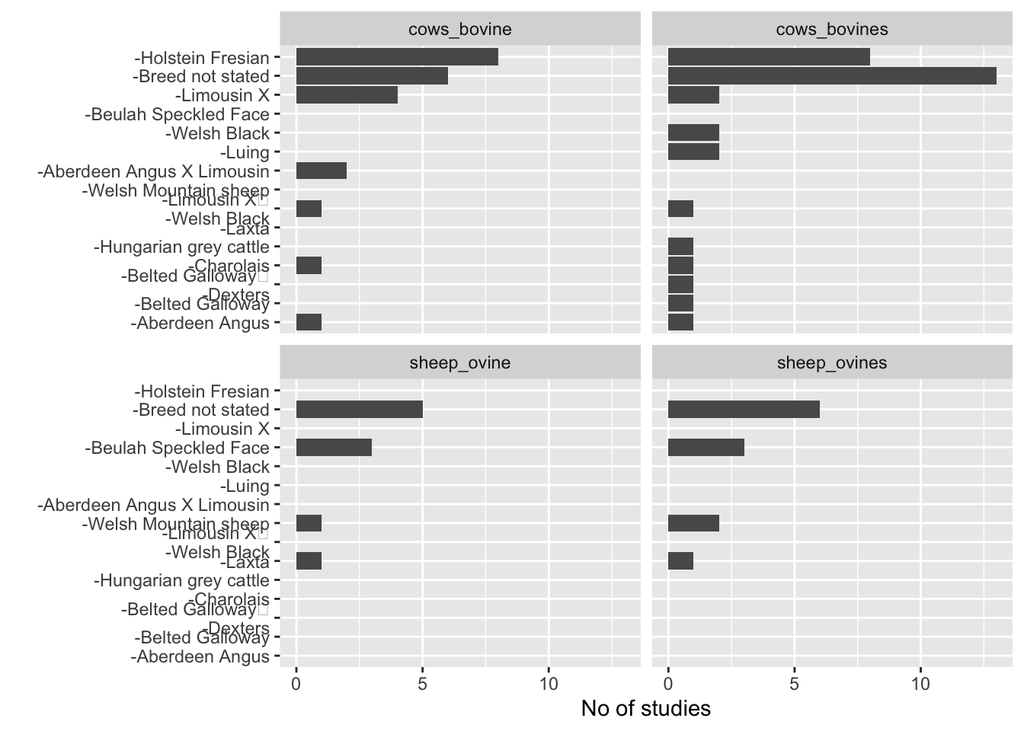

```r
#| label: faceted (small multiples)

grouped |>
  drop_na() |>
  ggplot(aes(reorder(breed, n), n)) +
  geom_col(position = "dodge") +
  coord_flip() +
  labs(x = "",
       y = "No of studies") +
  #scale_y_continuous(labels = scales::percent_format()) +
  facet_wrap(~herbivore)
```